# Red Wine Quality Data Analysis by Paul Hsiao

This analysis is focused on the red wine dataset. The red Wine dataset contains 1,599 red wines with 11 variables on the chemical properties of the wine. At least 3 wine experts rated the quality of each wine, providing a rating between 0 (very bad) and 10 (very excellent).

My original intention for this data analysis is to find out whether there is a direct relationship between quality and its chemical contents. However, the list of chemical included in the dataset missed out a few important ingredients, such as Phenols and Glycerol. These missed ingredient have big impact on quality of wine, such as smell. Due to this reason, the focus of this analysis has shifted to finding out the correlation between ingredients and quality in the dataset.

I’ll start with univariate analysis to study the distribution of each feature in the dataset. Pick up some features from summary of each feature for further investigation during bivariate analysis and multivariate analysis. Hopefully, I can come up with a good quality wine profile at the end of the analysis based on the information available.

Before jumping into analysis, lets take a look of the dataset first.

## Number of observations and variables in the red wine dataset

```
## [1] 1599   13
```

## Names of variables for the red wine dataset

```
##  [1] "X"                    "fixed.acidity"        "volatile.acidity"
##  [4] "citric.acid"          "residual.sugar"       "chlorides"
##  [7] "free.sulfur.dioxide"  "total.sulfur.dioxide" "density"
## [10] "pH"                   "sulphates"            "alcohol"
## [13] "quality"
```

## Statistics summary of the red wine dataset

```
##        X          fixed.acidity   volatile.acidity  citric.acid
##  Min.   :   1.0   Min.   : 4.60   Min.   :0.1200   Min.   :0.000
##  1st Qu.: 400.5   1st Qu.: 7.10   1st Qu.:0.3900   1st Qu.:0.090
##  Median : 800.0   Median : 7.90   Median :0.5200   Median :0.260
##  Mean   : 800.0   Mean   : 8.32   Mean   :0.5278   Mean   :0.271
##  3rd Qu.:1199.5   3rd Qu.: 9.20   3rd Qu.:0.6400   3rd Qu.:0.420
##  Max.   :1599.0   Max.   :15.90   Max.   :1.5800   Max.   :1.000
##  residual.sugar     chlorides       free.sulfur.dioxide
##  Min.   : 0.900   Min.   :0.01200   Min.   : 1.00
##  1st Qu.: 1.900   1st Qu.:0.07000   1st Qu.: 7.00
##  Median : 2.200   Median :0.07900   Median :14.00
##  Mean   : 2.539   Mean   :0.08747   Mean   :15.87
##  3rd Qu.: 2.600   3rd Qu.:0.09000   3rd Qu.:21.00
##  Max.   :15.500   Max.   :0.61100   Max.   :72.00
##  total.sulfur.dioxide    density             pH          sulphates
##  Min.   :  6.00       Min.   :0.9901   Min.   :2.740   Min.   :0.3300
##  1st Qu.: 22.00       1st Qu.:0.9956   1st Qu.:3.210   1st Qu.:0.5500
##  Median : 38.00       Median :0.9968   Median :3.310   Median :0.6200
##  Mean   : 46.47       Mean   :0.9967   Mean   :3.311   Mean   :0.6581
##  3rd Qu.: 62.00       3rd Qu.:0.9978   3rd Qu.:3.400   3rd Qu.:0.7300
##  Max.   :289.00       Max.   :1.0037   Max.   :4.010   Max.   :2.0000
##     alcohol      quality
##  Min.   : 8.40   3: 10
##  1st Qu.: 9.50   4: 53
##  Median :10.20   5:681
##  Mean   :10.42   6:638
##  3rd Qu.:11.10   7:199
##  Max.   :14.90   8: 18
```

# Univariate Plots Section

### Histograms for every feature and its summary statistics

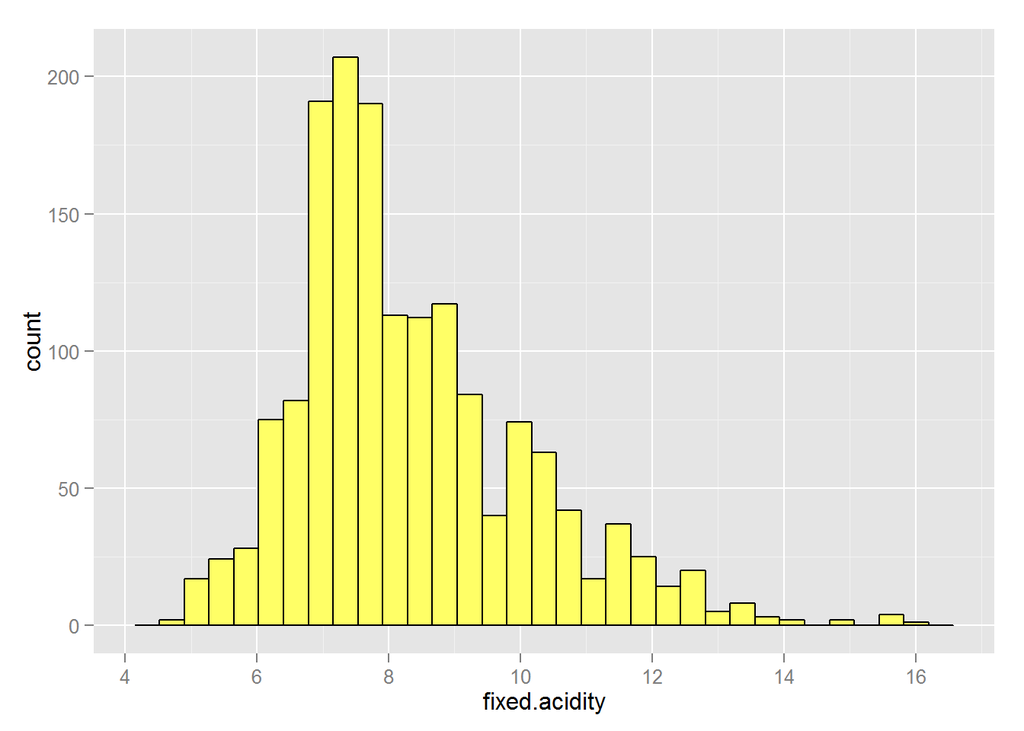

```
##    Min. 1st Qu.  Median    Mean 3rd Qu.    Max.
##    4.60    7.10    7.90    8.32    9.20   15.90
```

The fixed.acidity has median value of 7.9 and 3rd Quantile value of 9.2 while the max value goes as high as 15.9. Most likely these high value are outliers. From the plot, it suggests anything above 13.5 can be considered outliers.

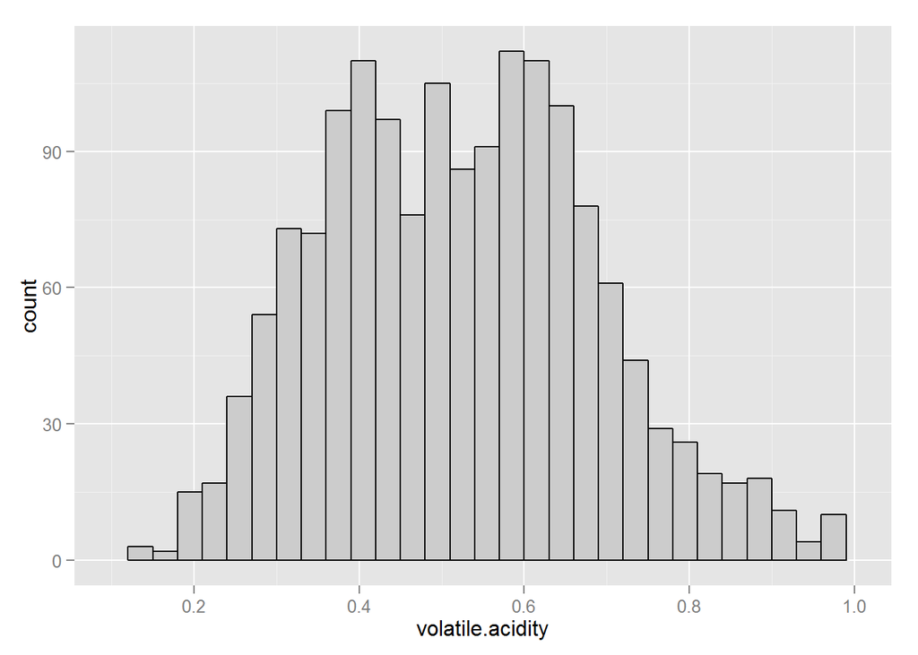

```
##    Min. 1st Qu.  Median    Mean 3rd Qu.    Max.
##  0.1200  0.3900  0.5200  0.5278  0.6400  1.5800
```

The volatile.acidity has mostly normal distribution with median value of 0.52. Some outliers appear at high value which have been excluded in the histogram.

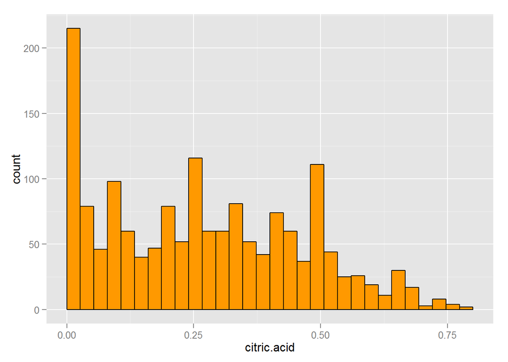

```
##    Min. 1st Qu.  Median    Mean 3rd Qu.    Max.
##   0.000   0.090   0.260   0.271   0.420   1.000
```

The citric.acid is a interesting feature. It has high count with value 0. Could this suggest wine makers are trying to get rid of this feature or it simply be consumed completely during fermentation process? I’ll have a further discussion about this later.

In terms of distribution, most wines are falling in the lower half. It has highest peak count at 0, two small peak count at around 0.25 and 0.5.

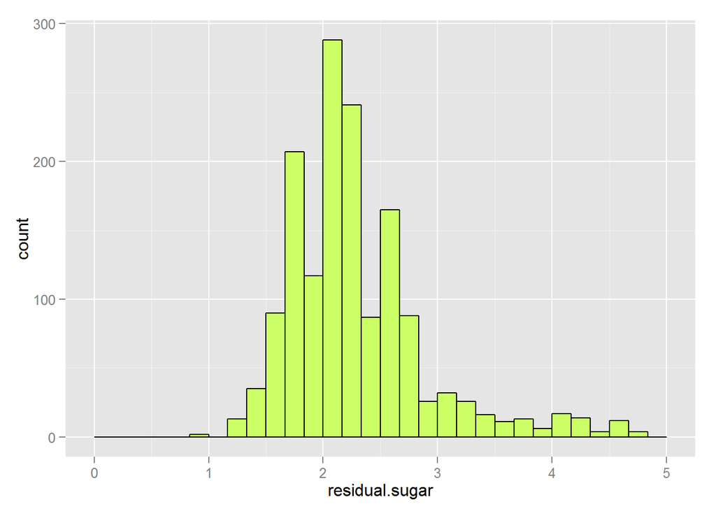

```
##    Min. 1st Qu.  Median    Mean 3rd Qu.    Max.
##   0.900   1.900   2.200   2.539   2.600  15.500
```

The residual.sugar has has normal distribution with median value of 2.2. It has 3rd quantile value of 2.6 with max value 15.5. So majority of wines have low residual.sugar level while some outliers exist at much higher level.

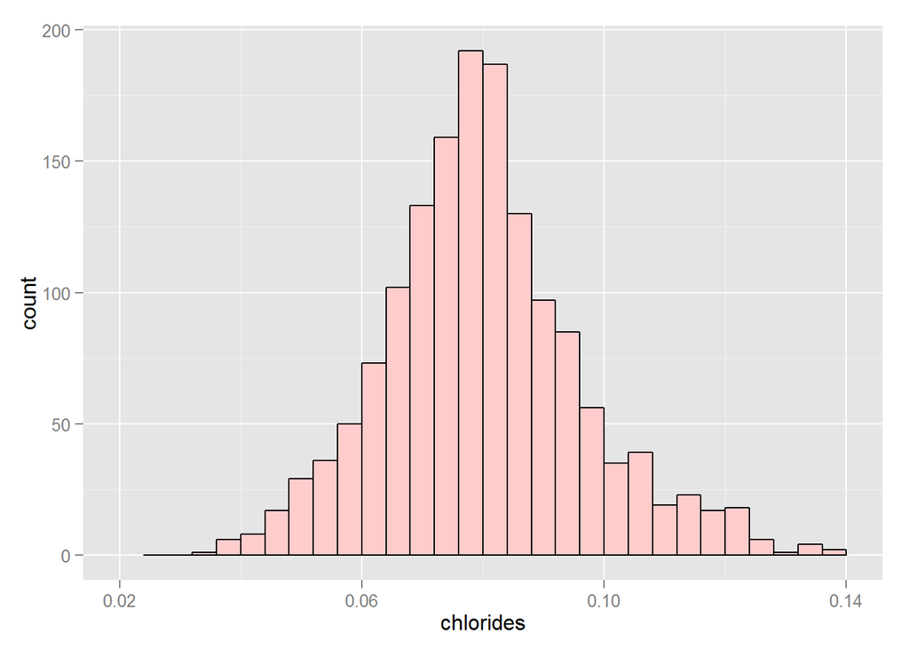

```
##    Min. 1st Qu.  Median    Mean 3rd Qu.    Max.
## 0.01200 0.07000 0.07900 0.08747 0.09000 0.61100
```

The chlorides has a normal distribution with median value 0.079. Majority of wine makers control this feature within the narrow range between 0.07 and 0.09. There are some outliers having the chlorides at above 0.6 level which is more than 6 times of 3rd quantile level. The chlorides in wine are from salt. Its level in the wine depends on geographic and geologic condition of the grape source.

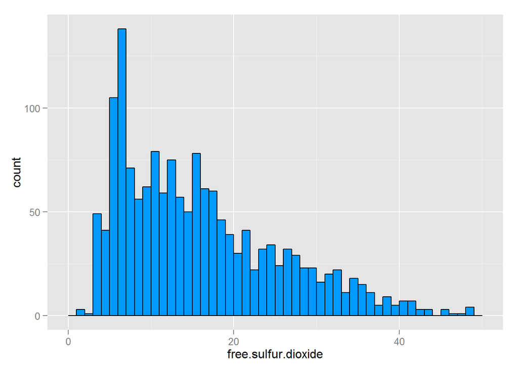

```
##    Min. 1st Qu.  Median    Mean 3rd Qu.    Max.
##    1.00    7.00   14.00   15.87   21.00   72.00
```

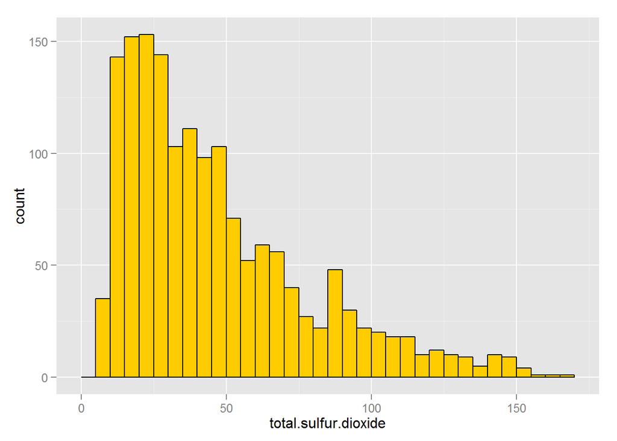

```
##    Min. 1st Qu.  Median    Mean 3rd Qu.    Max.
##    6.00   22.00   38.00   46.47   62.00  289.00
```

Here I put the discussions for free.sulfur.dioxide and total.sulfur.dioxide together. Both have “skewed right” distribution. Majority of wines have free.sulfur.dioxide and total.sulfur.dioxide at lower range. There are outliers for both features, especially for total.sulfur.dioxide.

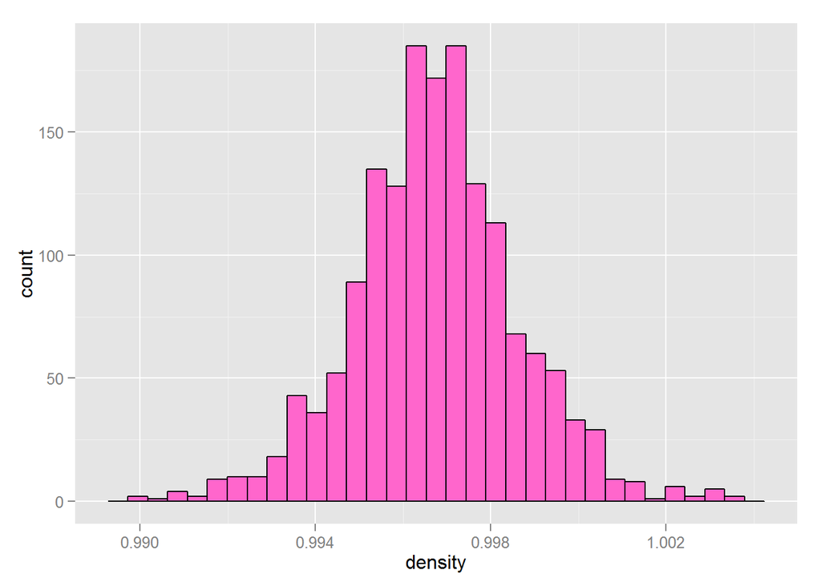

```
##    Min. 1st Qu.  Median    Mean 3rd Qu.    Max.
##  0.9901  0.9956  0.9968  0.9967  0.9978  1.0040
```

Density has a normal distribution with median value 0.9968.

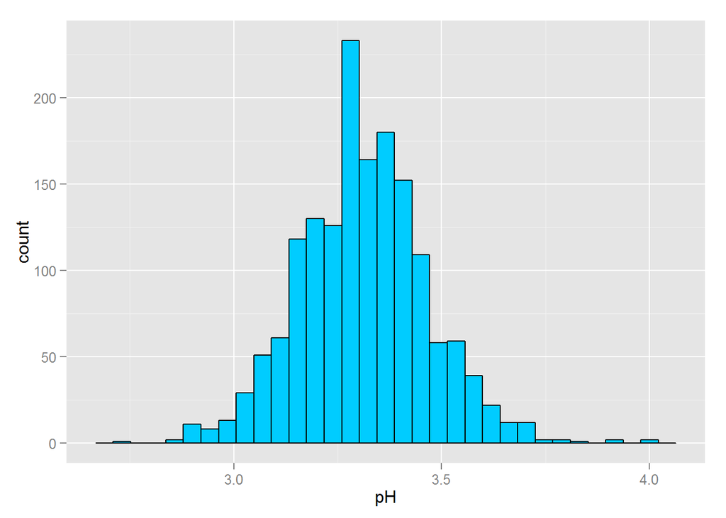

```
##    Min. 1st Qu.  Median    Mean 3rd Qu.    Max.
##   2.740   3.210   3.310   3.311   3.400   4.010
```

pH has a normal distribution with median value of 3.31.

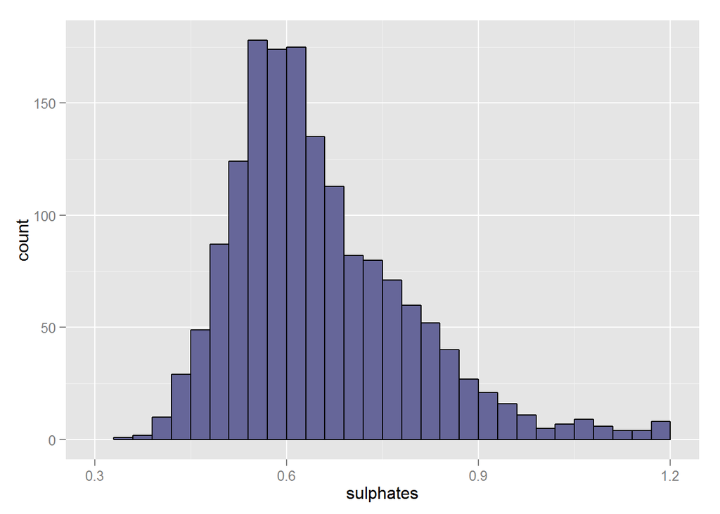

```
##    Min. 1st Qu.  Median    Mean 3rd Qu.    Max.
##  0.3300  0.5500  0.6200  0.6581  0.7300  2.0000
```

The sulphates has a little skewed right distribution. Its median value is 062. Max value of 2.0 which is considered outlier.

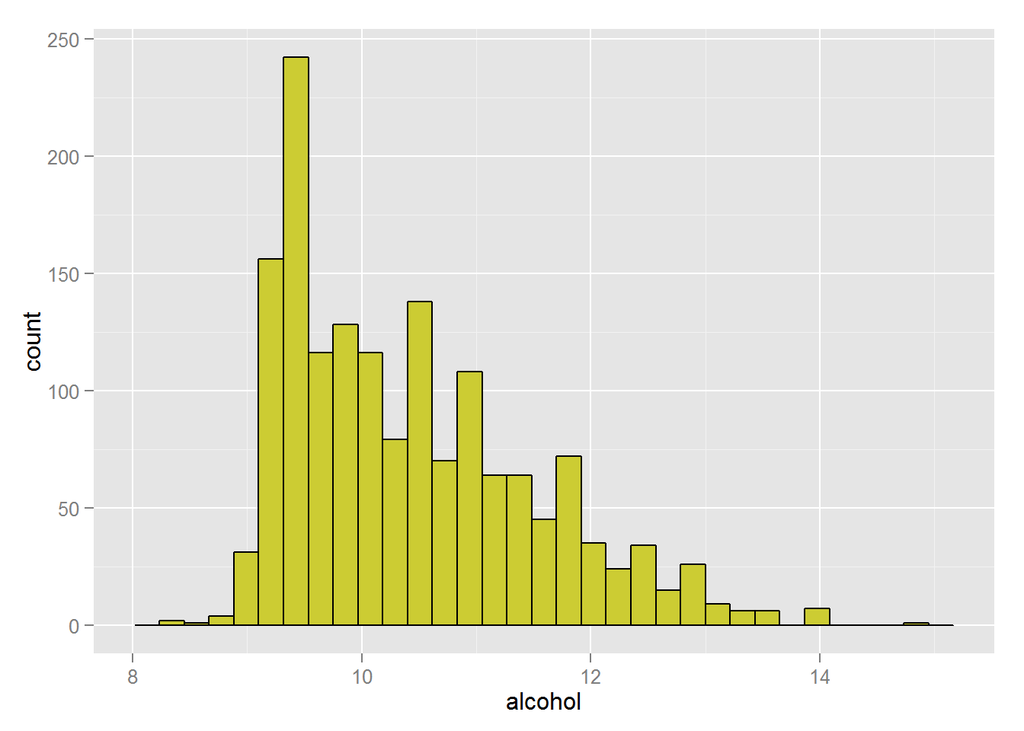

```
##    Min. 1st Qu.  Median    Mean 3rd Qu.    Max.
##    8.40    9.50   10.20   10.42   11.10   14.90
```

The alcohol has a “skewed right” distribution. The median value is 10.20 while the max value is 14.90.

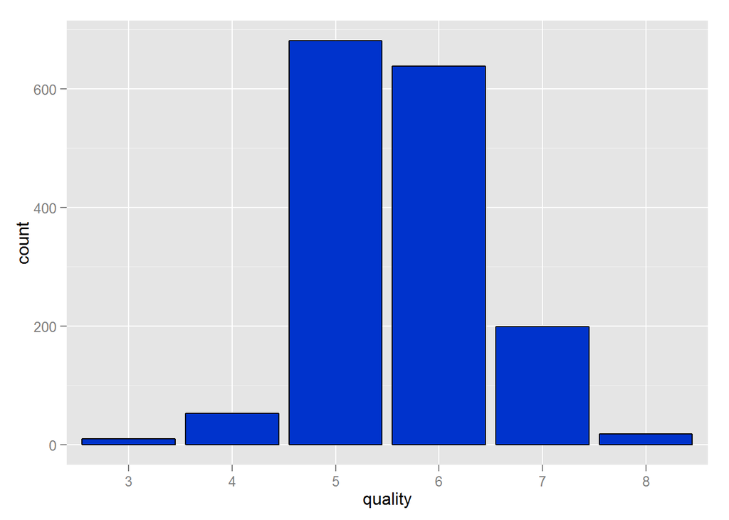

The quality has only 6 value. Majority of wines are in the middle quality levels. However, the quality value 7 has a count of 200 which is much higher than quality value 4.

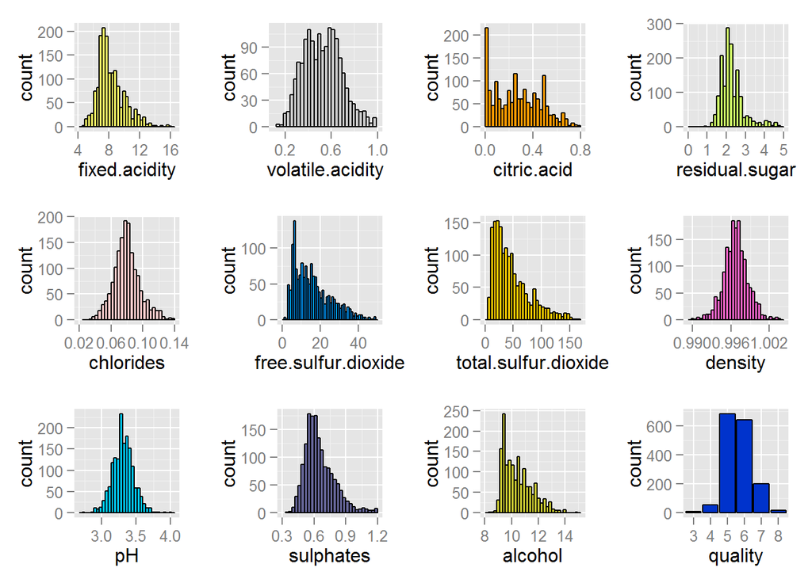

These histograms show the distribution of each feature in the dataset. The final grid plot provides a summary. We notices there are a few features showing ‘skewed right’ histograms, such as total.sulfur.dioxide, chlorides, alcohol, etc. That might suggest the wine makers want to control the feature contents under certain level. All features have median value in the middle or lower range.

## Re-examine the histograms using different x-scale

Here I use different x-scale to plot the histogram for the same attribute, fixed.acidity. I wonder whether different x-scale can expose some special distribution information. Let’s have a look of the plots.

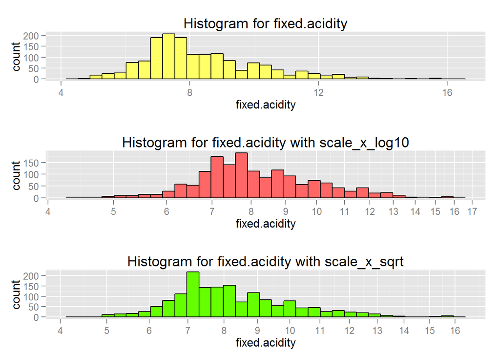

These three plots shows different shape of distribution due to different x scale is taken. The plot with log10 on x-axis gives a more normalized shape.

# Univariate Analysis

### What is the structure of your dataset?

```
## 'data.frame':    1599 obs. of  13 variables:
##  $ X                   : int  1 2 3 4 5 6 7 8 9 10 ...
##  $ fixed.acidity       : num  7.4 7.8 7.8 11.2 7.4 7.4 7.9 7.3 7.8 7.5 ...
##  $ volatile.acidity    : num  0.7 0.88 0.76 0.28 0.7 0.66 0.6 0.65 0.58 0.5 ...
##  $ citric.acid         : num  0 0 0.04 0.56 0 0 0.06 0 0.02 0.36 ...
##  $ residual.sugar      : num  1.9 2.6 2.3 1.9 1.9 1.8 1.6 1.2 2 6.1 ...
##  $ chlorides           : num  0.076 0.098 0.092 0.075 0.076 0.075 0.069 0.065 0.073 0.071 ...
##  $ free.sulfur.dioxide : num  11 25 15 17 11 13 15 15 9 17 ...
##  $ total.sulfur.dioxide: num  34 67 54 60 34 40 59 21 18 102 ...
##  $ density             : num  0.998 0.997 0.997 0.998 0.998 ...
##  $ pH                  : num  3.51 3.2 3.26 3.16 3.51 3.51 3.3 3.39 3.36 3.35 ...
##  $ sulphates           : num  0.56 0.68 0.65 0.58 0.56 0.56 0.46 0.47 0.57 0.8 ...
##  $ alcohol             : num  9.4 9.8 9.8 9.8 9.4 9.4 9.4 10 9.5 10.5 ...
##  $ quality             : Factor w/ 6 levels "3","4","5","6",..: 3 3 3 4 3 3 3 5 5 3 ...
```

All the features have numeric data type originally. The quality is transformed between numeric and factor for plotting and statistics calculation purpose.

### What is/are the main feature(s) of interest in your dataset?

fixed.acidity, residual.sugar and density

These three attributes have influence on the acid taste, sweet taste and color which affect the popularity of the wine.

### What other features in the dataset do you think will help support your investigation into your feature(s) of interest?

1. pH - pH should have strong negative correlation with fixed.acidity.
2. alcohol - Alcohol is converted from sugar through fermentation process.

### Did you create any new variables from existing variables in the dataset?

Yes, I created two new variables.:

1. **pH.bucket**

This variable is created as a factor variable which is used for certain ploting in this analysis report.

2. **total.acidity**

This variable is created to check whether there is any relationship between these three ‘acid’ related features.

total.acidity = fixed.acidity + volatile.acidity + citric.acid

Summary of total.acidity

```
##    Min. 1st Qu.  Median    Mean 3rd Qu.    Max.
##   5.270   7.827   8.720   9.118  10.070  17.050
```

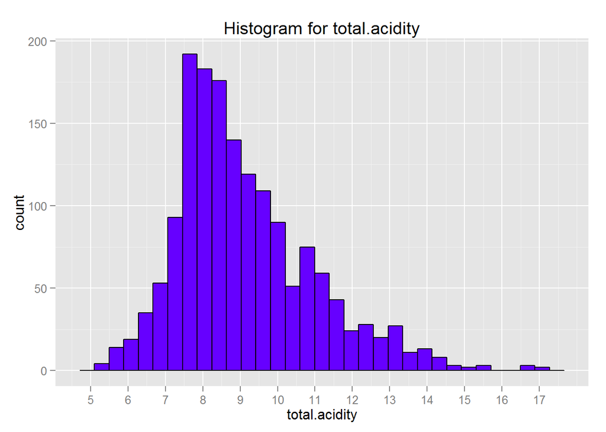

### Compare the histograms of total.acidity and other acidity features

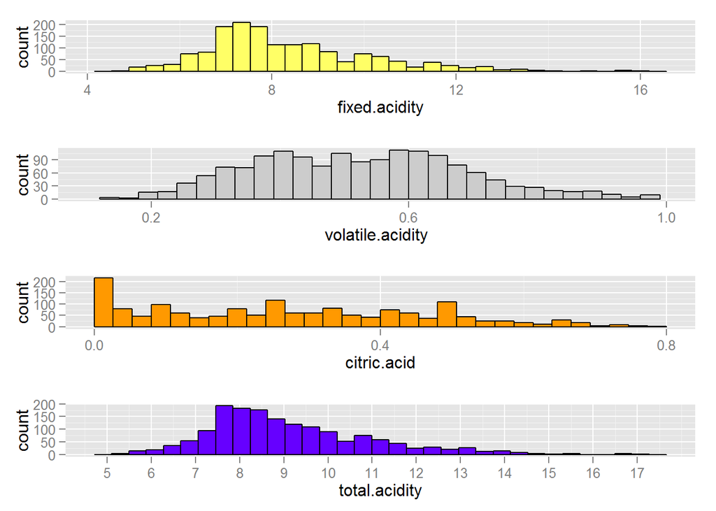

Here we see the fixed.acidity seems to have major influence on the total.acidity which is not a surprise. The quantity for volatile.acidity and citric.acid are much smaller compared to fixed.acidity. So, fixed.acidity has very high correlation to the total.acidity.

How about the relationship between acidity and pH value? I’ll visit this topic in bivariate analysis.

I also want to see the whether the relationship between total acidity and quality can be correlated better than the given acidity features.

Further discussion for these two variables will be included in bivariate analysis section.

### Of the features you investigated, were there any unusual distributions? Did you perform any operations on the data to tidy, adjust, or change the form of the data? If so, why did you do this?

#### Unusual distributions

There are two features that posses unusual distributions:

**1. citric.acid**

citric.acid summary and lowest 6 citric.acid level count:

```
##    Min. 1st Qu.  Median    Mean 3rd Qu.    Max.
##   0.000   0.090   0.260   0.271   0.420   1.000
```

```
##
##    0 0.01 0.02 0.03 0.04 0.05
##  132   33   50   30   29   20
```

For citric.acid, there are 132 observations having 0 value (out of total 1599 observations).

According to web site Calwineries article (http://www.calwineries.com/learn/wine-chemistry/wine-acids/citric-acid),

*Citric acid plays a major role in the biochemisty of the grape vine and bacteria…. However, its role in wine is far less important. Most, if not all of the citric acid naturally present in the grapes is consumed by bacteria during fermentation.*

*The major disadvantage of adding citric acid is its microbial instability.*

This explains why there are 0-level citric.acid.

**2. chlorides**

chlorides summary:

```
##    Min. 1st Qu.  Median    Mean 3rd Qu.    Max.
## 0.01200 0.07000 0.07900 0.08747 0.09000 0.61100
```

Majority of observations have chlorides level falls under 0.09. However, the maximum chlorides level reached 0.611 which is more than 7 times of the median. This could indicate there are some outliers to cause the high maximum chlorides value. We’ll look at this outlier further later in the bivariate analysis.

#### Operations on the data to tidy, adjust, or change the form of the data

Due to the nature of quality variable, I transformed the quality variable from numeric to factor. I did not do any other tidy nor adjust because it is not necessary for my analysis.

# Bivariate Plots Section

## Scatterplot matrices

First of all, we’ll have a look of the Scatterplot matrices of all features. This matrices will provide us a rough idea about correlation between all features. To make the scatterplot matrices more readable, variables are renamed to shorter names for this scatterplot matrices. The Scatterplot matrices is also stored in a separate file (red_wine_Scatterplot_matrices.JPG) for better viewing.

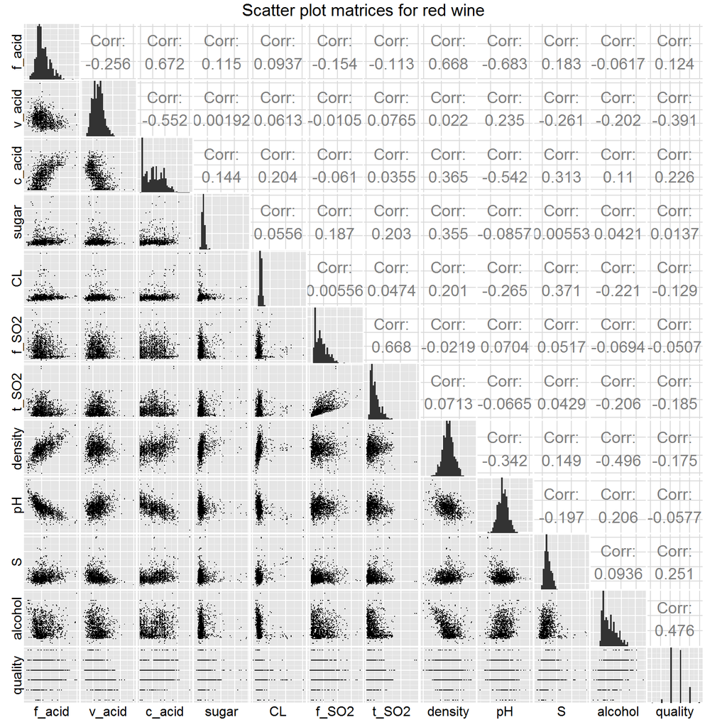

**Abbreviation:**  
f_acid - fixed.acidity,  
v_acid - volatile.acidity,  
c_acid - citric.acid,  
sugar - residual.sugar,  
CL - chlorides,  
f_SO2 - free.sulfur.dioxide,  
t_SO2 - total.sulfur.dioxide,  
S - sulphates

From the Scatterplot Matrices, the main observations are:

1. fixed.acidity and density have a positive Correlation Coefficient of 0.668. This is a interesting point worthy further investigation. According to web site ‘http://winefolly.com/tutorial/how-to-taste-red-wine/’, for red wine, higher density means more material is extracted from the grape skin into the wine. That will also lead to darker color.
2. fixed.acidity and pH have a negative Correlation Coefficient -0.683. This is expected as higher acidity will decrease the pH value.
3. fixed.acidity and citric.acid have positive Correlation Coefficient of 0.672. As citric.acid is part of fixed.acidity, the high positive correlation is reasonable.

## Correlation between quality and features

Here, we’ll use histogram and boxplot to examine the correlation between quality and following features.

- fixed.acidity
- pH
- residual.sugar
- alcohol
- density
- chlorides
- total.sulfur.dioxide

In the below histograms, we’ll show composition of each quality. In the boxplot, we’ll mark the mean value per quality. With these plots, we can observe the influence of each feature on the quality.

### fixed.acidity vs quality

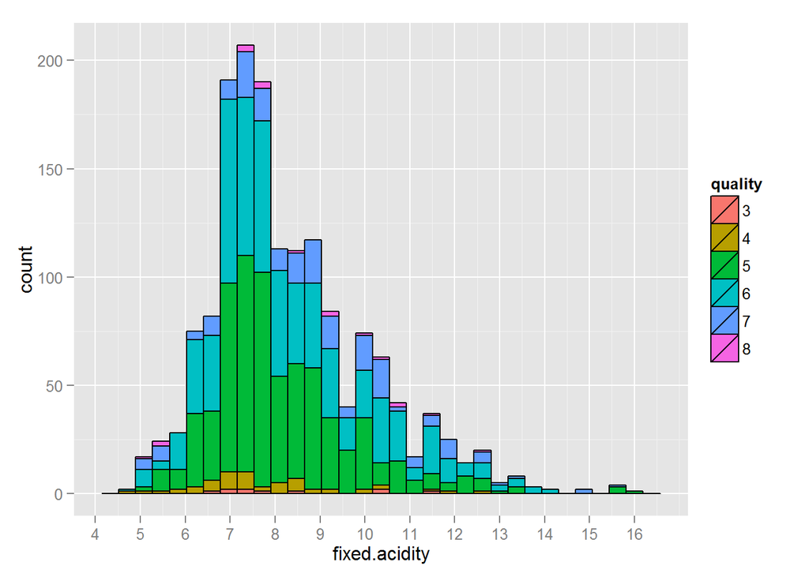

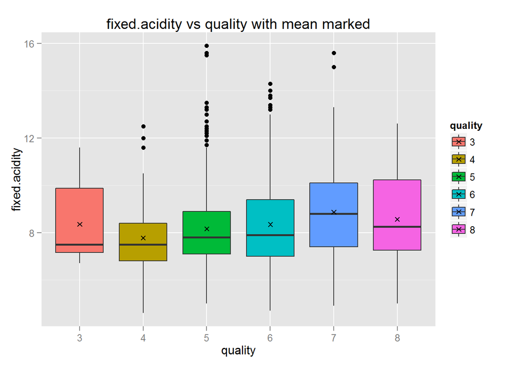

```
## Source: local data frame [6 x 6]
##
##   quality Min Median     Mean  Max   n
## 1       3 6.7   7.50 8.360000 11.6  10
## 2       4 4.6   7.50 7.779245 12.5  53
## 3       5 5.0   7.80 8.167254 15.9 681
## 4       6 4.7   7.90 8.347179 14.3 638
## 5       7 4.9   8.80 8.872362 15.6 199
## 6       8 5.0   8.25 8.566667 12.6  18
```

Correlation between fixed.acidity and quality is **0.1240516**

From the plots and summary, we notice the higher quality wines have higher fixed.acidity median value.

### pH vs quality

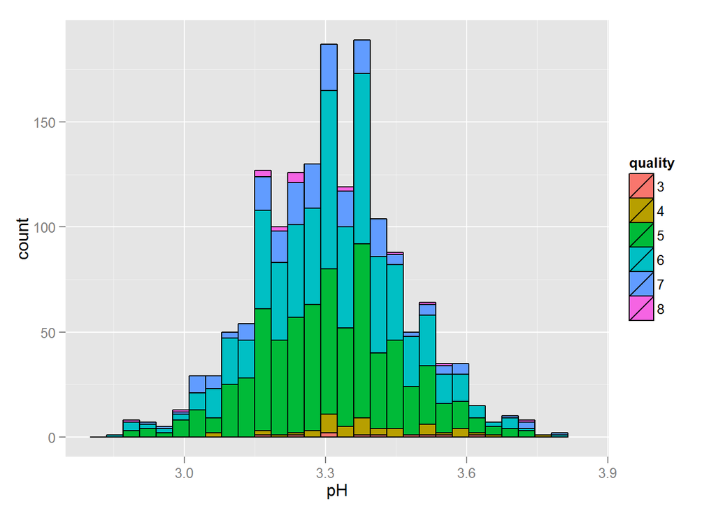

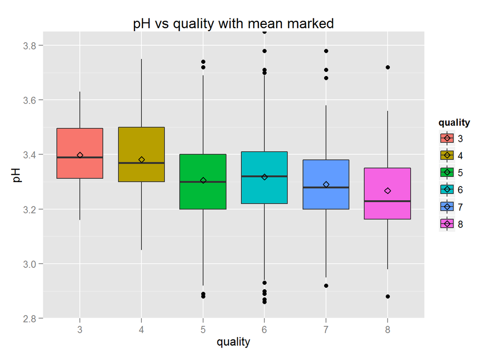

```
## Source: local data frame [6 x 6]
##
##   quality  Min Median     Mean  Max   n
## 1       3 3.16   3.39 3.398000 3.63  10
## 2       4 2.74   3.37 3.381509 3.90  53
## 3       5 2.88   3.30 3.304949 3.74 681
## 4       6 2.86   3.32 3.318072 4.01 638
## 5       7 2.92   3.28 3.290754 3.78 199
## 6       8 2.88   3.23 3.267222 3.72  18
```

Correlation between pH and quality is **-0.0577314**

From the plots and summary above, it is observed the higher quality wines have lower pH median value. This observation matches with the previous observation for fixed.acidity. The higher fixed.acidity it has, the lower pH value we got.

### residual.sugar vs quality

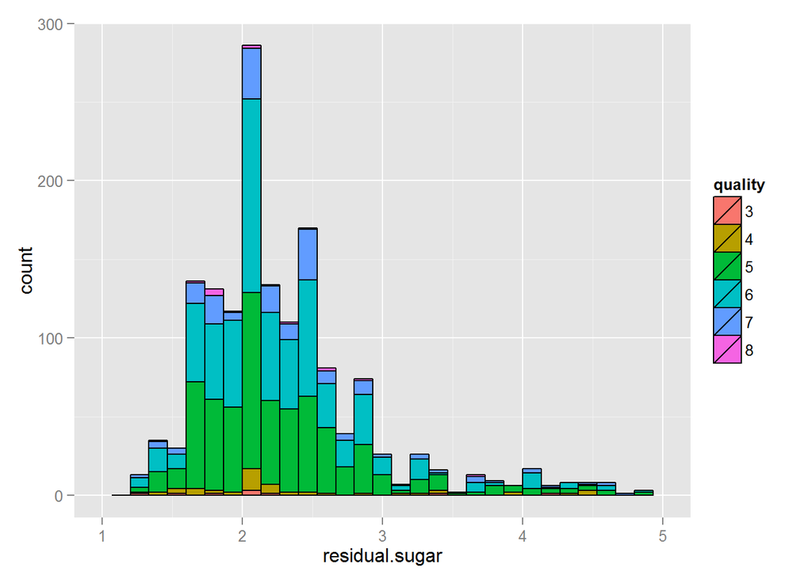

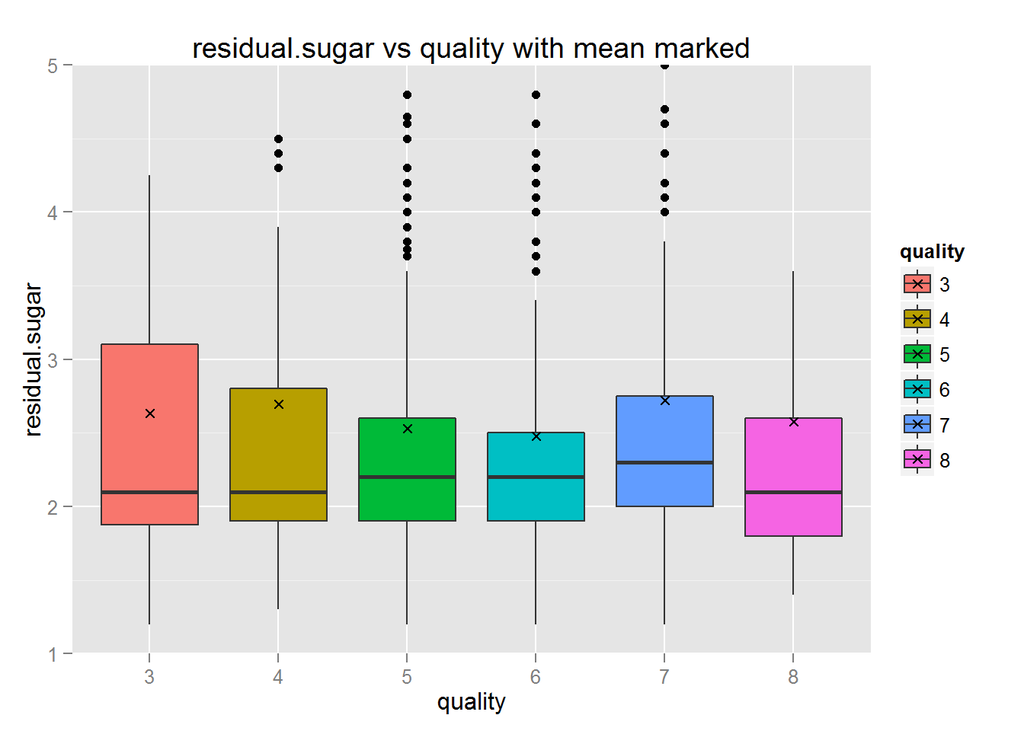

```
## Source: local data frame [6 x 6]
##
##   quality Min Median     Mean  Max   n
## 1       3 1.2    2.1 2.635000  5.7  10
## 2       4 1.3    2.1 2.694340 12.9  53
## 3       5 1.2    2.2 2.528855 15.5 681
## 4       6 0.9    2.2 2.477194 15.4 638
## 5       7 1.2    2.3 2.720603  8.9 199
## 6       8 1.4    2.1 2.577778  6.4  18
```

Correlation between residual.sugar and quality is **0.0137316**

From the plots and summary above, the residual.sugar level has very low correlation with quality. It looks like most wine makers control the residual.sugar level to low range. However, we can see there are many outliers. It might be for the purpose meeting demand from certain market segment.